# Draw sampling map using R

Zhijun Wang

21/05/2021

# 1 Introduction

This is an R Markdown document to summary the necessary Data science in food applications.

The datasets were from built-in dataset in R packages, and the open-access resources from Quadram Institute. [Example Datasets for Download](https://csr.quadram.ac.uk/example-datasets-for-download/).These datasets are distributed under the terms of **the Creative Commons Attribution License**, which permits unrestricted use, distribution and reproduction in any medium, provided the original work is properly cited.

# 2 Using R for maps

Many articles need to use maps to display some data. Professional drawing software such as ARCGIS is more expensive and takes a long time to learn. The advantage of drawing with R is that everyone can install R and R maps have no copyright issues and are easy to use. The main R packages used are **ggplot2**, **sf**, **rnaturalearth**, **rnaturalearthdata**, etc. When you need to modify the picture, you only need to modify the code, which eliminates the cumbersome modification of the picture.

> To determine the origin of the sample, so samples from different countries are collected, and the location of the origin needs to be marked on the map.

```r
library(rnaturalearth)
library(rnaturalearthdata)
library(ggspatial)
library(sf)
library(ggplot2)
library(gpclib)
library(maptools)
library(maps)
library(mapdata)
library(sp)
library(raster)
library(RColorBrewer)
library(rgeos)
```

The sampling sits could be created by R:

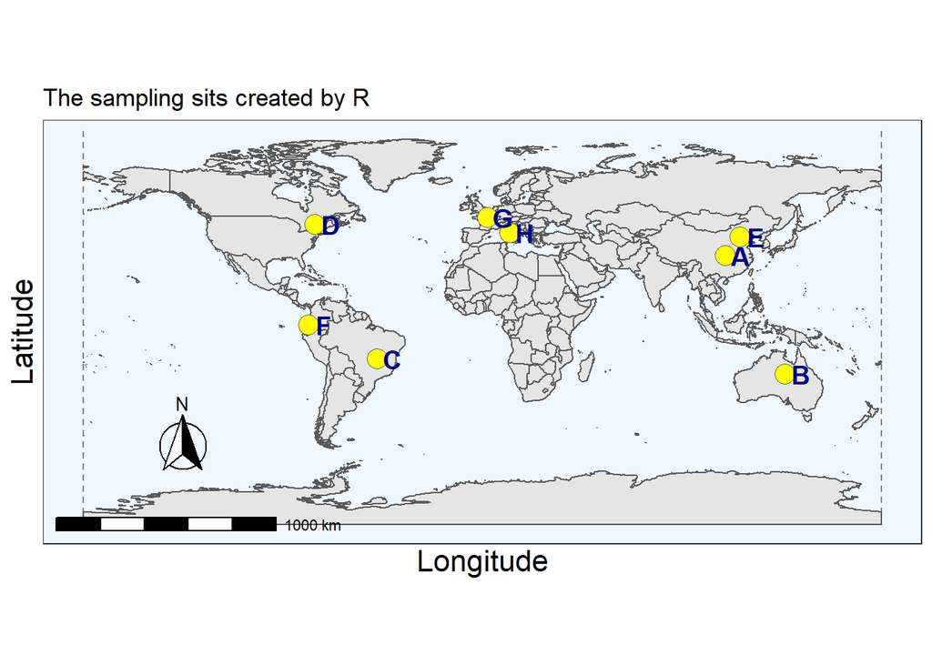